# Data Mining Coursework

### 1.1.5 Distribution of DeterminandC w.r.t WBCategory

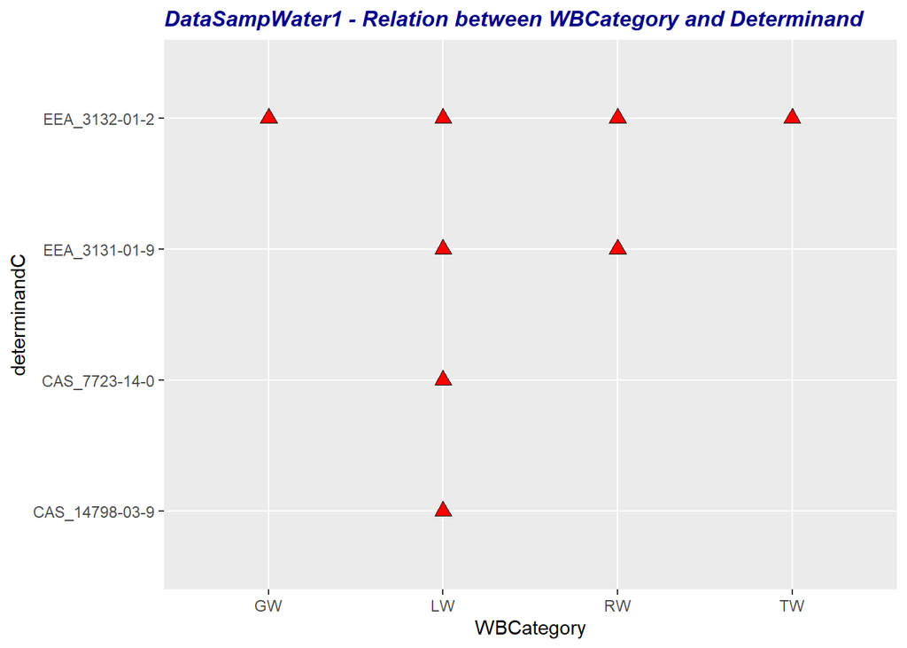

```r
ggplot(DataSampWater1, aes(x=WBCategory,determinandC )) +
    geom_point(shape=24,fill = "red",size = 3) + ggtitle("DataSampWater1 - Relation between WBCategory and Determinand") + theme(plot.title = element_text(color="dark blue", size=12, face="bold.italic"))
```

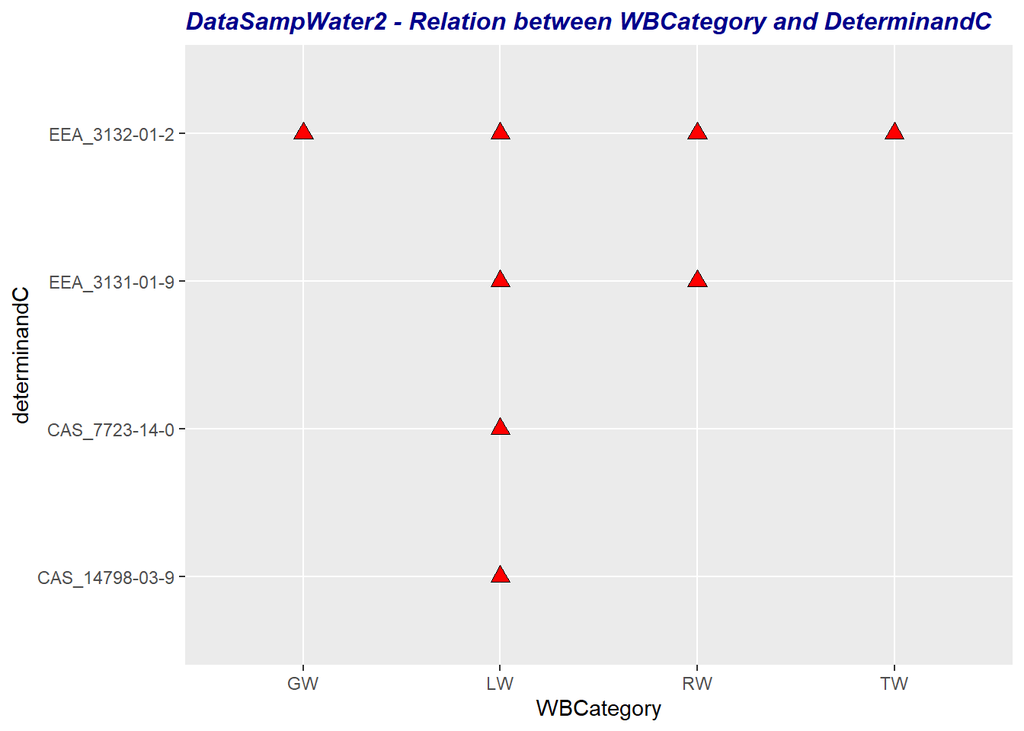

```r
ggplot(DataSampWater2, aes(x=WBCategory,determinandC )) +
    geom_point(shape=24,fill = "red",size = 3) + ggtitle("DataSampWater2 - Relation between WBCategory and DeterminandC")+ theme(plot.title = element_text(color="dark blue", size=12, face="bold.italic"))
```

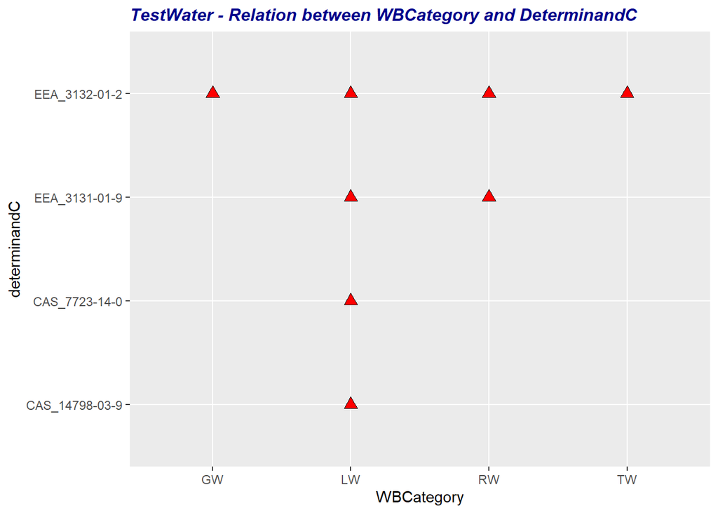

```r
ggplot(TestWater, aes(x=WBCategory,determinandC )) +
    geom_point(shape=24,fill = "red",size = 3)+ ggtitle("TestWater - Relation between WBCategory and DeterminandC")+ theme(plot.title = element_text(color="dark blue", size=12, face="bold.italic"))
```

The above plots are useful in seeing the attribute of ‘DeteminandC’ with respect to ‘WBCategory’. All types of ‘DeterminanC’ can be seen in LW. GW and TW only have EEA_3132-01-2 in it. RW has the two ‘EEA’ types in it , which is associated with oxygen.

### 1.1.6 Distribution of between the WB category assigned and the determinandC

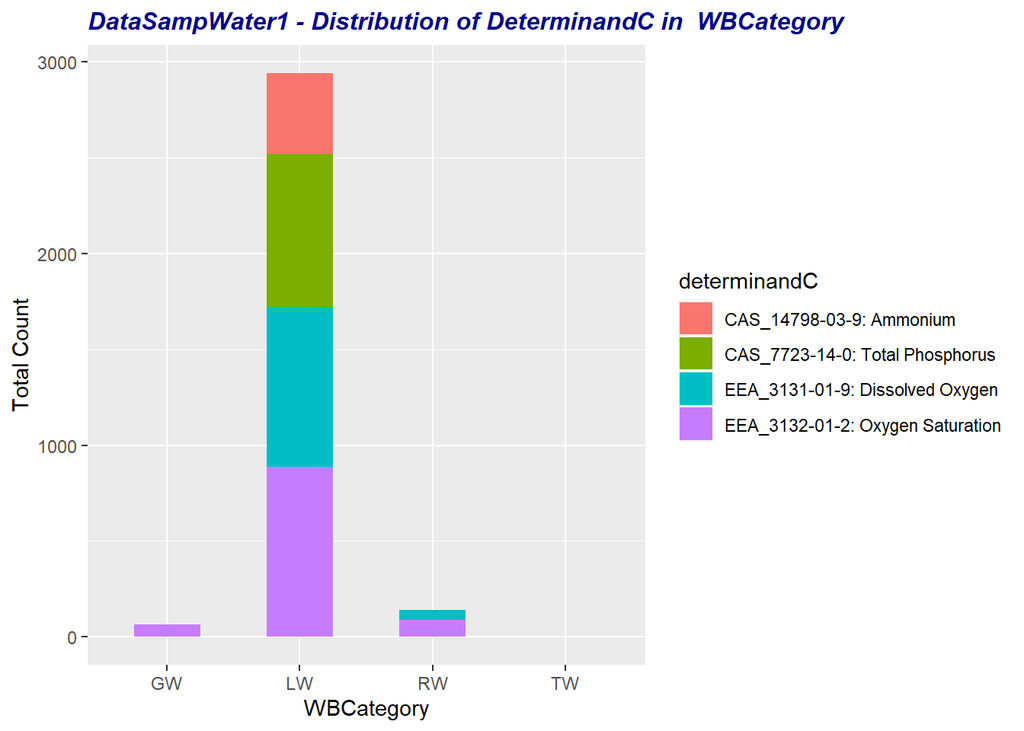

```r
# plotting levels of Determinand code: Ammonium , Total Phosphorus ,Dissolved Oxygen , Oxygen Saturation in WBCategory

ggplot(DataSampWater1,aes(x =WBCategory ,fill = determinandC )) + geom_bar(width = 0.5) + xlab("WBCategory") + ylab("Total Count")+ ggtitle("DataSampWater1 - Distribution of DeterminandC in  WBCategory") + theme(plot.title = element_text(color="dark blue", size=12, face="bold.italic"))+ scale_fill_discrete(labels = c("CAS_14798-03-9: Ammonium","CAS_7723-14-0: Total Phosphorus","EEA_3131-01-9: Dissolved Oxygen","EEA_3132-01-2: Oxygen Saturation"))
```

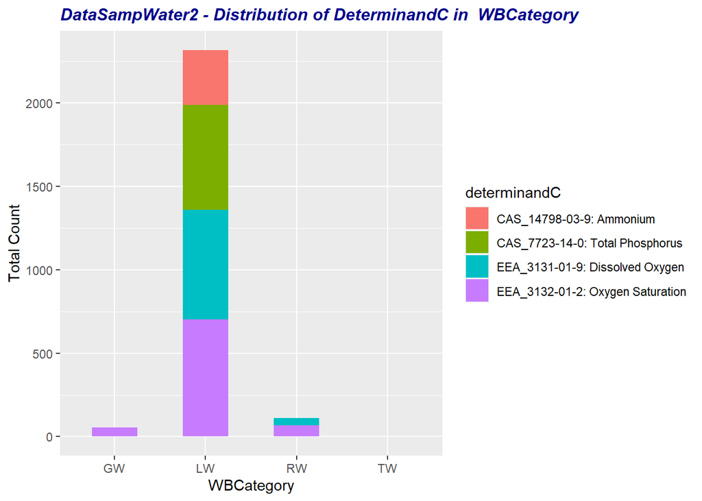

```r
ggplot(DataSampWater2,aes(x =WBCategory ,fill = determinandC )) + geom_bar(width = 0.5) + xlab("WBCategory") + ylab("Total Count")+ ggtitle("DataSampWater2 - Distribution of DeterminandC in  WBCategory") + theme(plot.title = element_text(color="dark blue", size=12, face="bold.italic"))+ scale_fill_discrete(labels = c("CAS_14798-03-9: Ammonium","CAS_7723-14-0: Total Phosphorus","EEA_3131-01-9: Dissolved Oxygen","EEA_3132-01-2: Oxygen Saturation"))
```

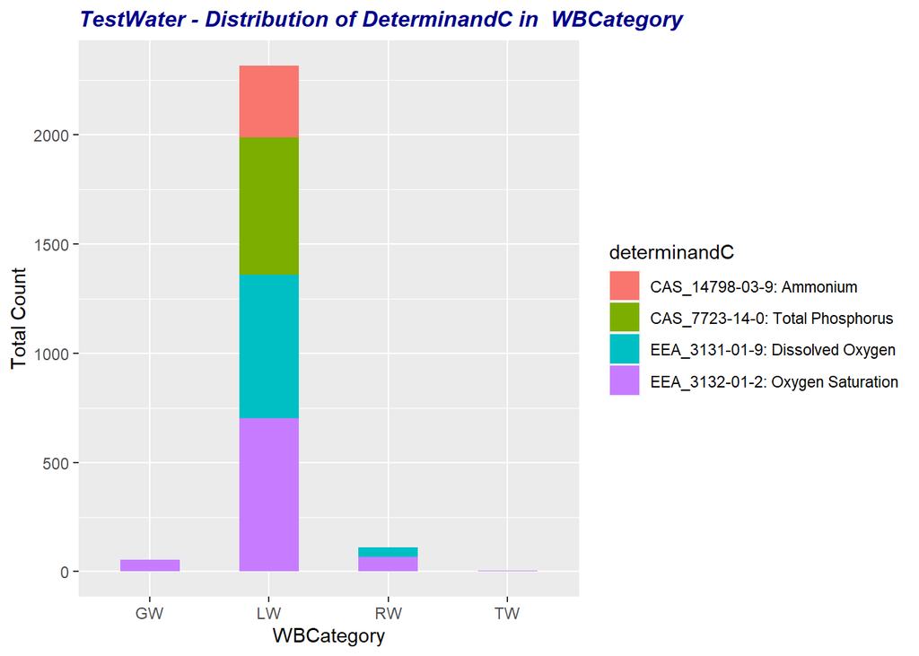

```r
ggplot(TestWater,aes(x =WBCategory ,fill = determinandC )) + geom_bar(width = 0.5) + xlab("WBCategory") + ylab("Total Count")+ ggtitle("TestWater - Distribution of DeterminandC in  WBCategory") + theme(plot.title = element_text(color="dark blue", size=12, face="bold.italic"))+ scale_fill_discrete(labels = c("CAS_14798-03-9: Ammonium","CAS_7723-14-0: Total Phosphorus","EEA_3131-01-9: Dissolved Oxygen","EEA_3132-01-2: Oxygen Saturation"))
```

Oxygen Saturation is found in all four of the ‘WBCatergory’, which is to be expected. Ammonium and Phosphorus is found only in Lake water which is interesting in terms of an environmental perspective.

### 1.1.7 Relationship between the WBcategory and the siteIDscheme

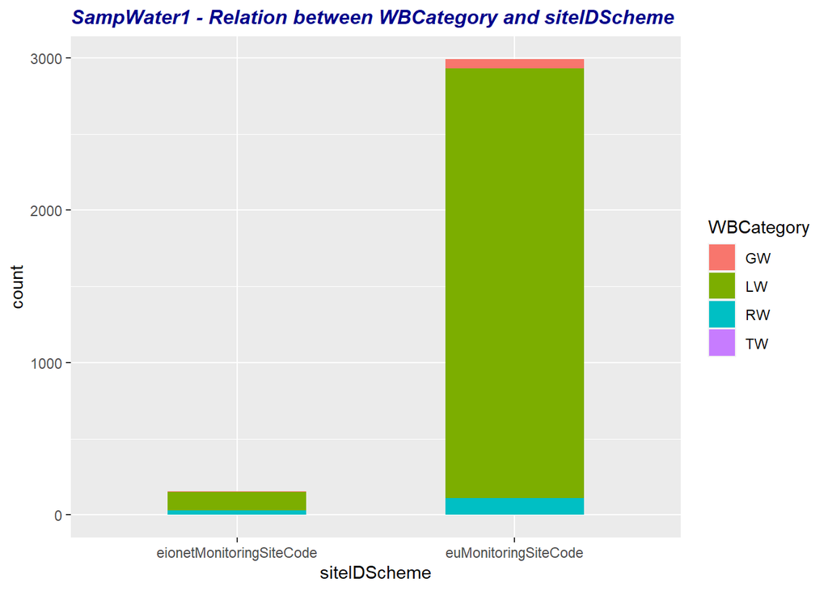

```r
# Plotting the siteIDScheme in relation to WBCategory for all three Datasets

ggplot(DataSampWater1,aes(x = siteIDScheme,fill = WBCategory)) + geom_bar(width = 0.5)+ggtitle("SampWater1 - Relation between WBCategory and siteIDScheme") + theme(plot.title = element_text(color="dark blue", size=12, face="bold.italic"))
```

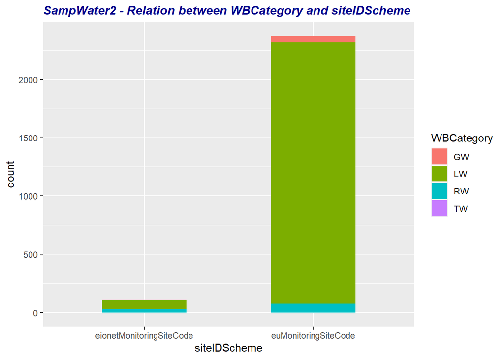

```r
ggplot(DataSampWater2,aes(x = siteIDScheme,fill = WBCategory)) + geom_bar(width = 0.5) + ggtitle("SampWater2 - Relation between WBCategory and siteIDScheme") + theme(plot.title = element_text(color="dark blue", size=12, face="bold.italic"))
```

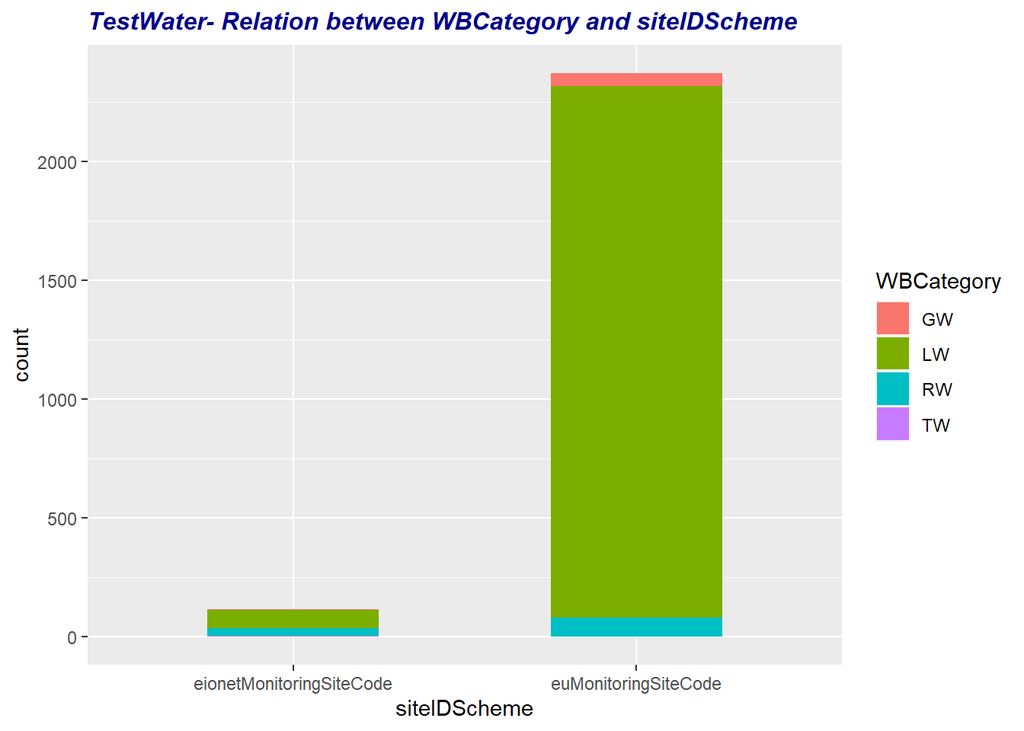

```
## DataSampWater1$siteIDScheme: eionetMonitoringSiteCode
##                    siteIDScheme WBCategory         determinandC  analysed
##  eionetMonitoringSiteCode:154   GW:  1     CAS_14798-03-9:24    total:154
##  euMonitoringSiteCode    :  0   LW:122     CAS_7723-14-0 :37
##                                 RW: 30     EEA_3131-01-9 :37
##                                 TW:  1     EEA_3132-01-2 :56
##
##
##
##    media        NSamples         minValue           meanValue
##  water:154   Min.   : 1.000   Min.   :  0.00258   Min.   :  0.00400
##              1st Qu.: 2.000   1st Qu.:  0.01801   1st Qu.:  0.02425
##              Median : 2.000   Median :  6.86000   Median :  8.23500
##              Mean   : 3.513   Mean   : 16.96852   Mean   : 19.80906
##              3rd Qu.: 4.000   3rd Qu.: 10.80000   3rd Qu.: 11.81895
##              Max.   :13.000   Max.   :108.33300   Max.   :108.33300
##
##     maxValue               sd                               method
##  Min.   :  0.00515   Min.   : 0.00000   EN 25813:1992          :45
##  1st Qu.:  0.03220   1st Qu.: 0.00425   SFS 3026               :37
##  Median :  8.99750   Median : 0.55865   SFS 3032 + EN ISO 11732:24
##  Mean   : 22.48911   Mean   : 3.75977   SFS 3040               :28
##  3rd Qu.: 13.63000   3rd Qu.: 1.89496   SFS 3040 SFS-EN 25813  :20
##  Max.   :110.00000   Max.   :53.59400
##                      NA's   :24
## ------------------------------------------------------------
## DataSampWater1$siteIDScheme: euMonitoringSiteCode
##                    siteIDScheme  WBCategory         determinandC  analysed
##  eionetMonitoringSiteCode:   0   GW:  63    CAS_14798-03-9:396   total:2992
##  euMonitoringSiteCode    :2992   LW:2819    CAS_7723-14-0 :765
##                                  RW: 110    EEA_3131-01-9 :848
##                                  TW:   0    EEA_3132-01-2 :983
##
##
##
##    media         NSamples         minValue         meanValue
##  water:2992   Min.   : 1.000   Min.   :  0.000   Min.   :  0.00100
##               1st Qu.: 2.000   1st Qu.:  0.016   1st Qu.:  0.02576
##               Median : 2.000   Median :  6.190   Median :  7.80105
##               Mean   : 3.187   Mean   : 19.187   Mean   : 22.72884
##               3rd Qu.: 4.000   3rd Qu.: 34.666   3rd Qu.: 53.42825
##               Max.   :25.000   Max.   :104.000   Max.   :104.00000
##
##     maxValue               sd                              method
##  Min.   :  0.00129   Min.   : 0.0000   EN 25813:1992          :415
##  1st Qu.:  0.03337   1st Qu.: 0.0040   SFS 3026               :765
##  Median :  8.92350   Median : 0.8238   SFS 3032 + EN ISO 11732:396
##  Mean   : 26.13186   Mean   : 3.9242   SFS 3040               :693
##  3rd Qu.: 63.86750   3rd Qu.: 3.0564   SFS 3040 SFS-EN 25813  :723
##  Max.   :135.50000   Max.   :49.4970
##                      NA's   :290
```

```
## DataSampWater2$siteIDScheme: eionetMonitoringSiteCode
##                    siteIDScheme WBCategory         determinandC  analysed
##  eionetMonitoringSiteCode:112   GW: 1      CAS_14798-03-9: 9    total:112
##  euMonitoringSiteCode    :  0   LW:80      CAS_7723-14-0 :18
##                                 RW:30      EEA_3131-01-9 :28
##                                 TW: 1      EEA_3132-01-2 :57
##
##
##
##    media        NSamples        minValue          meanValue
##  water:112   Min.   : 1.00   Min.   : 0.00000   Min.   : 0.0060
##              1st Qu.: 2.00   1st Qu.: 0.09303   1st Qu.: 0.7848
##              Median : 2.00   Median : 7.75000   Median : 9.1094
##              Mean   : 4.33   Mean   :19.79148   Mean   :23.2792
##              3rd Qu.: 6.00   3rd Qu.:12.52000   3rd Qu.:33.3120
##              Max.   :16.00   Max.   :90.00000   Max.   :99.1000
##
##     maxValue               sd                             method
##  Min.   :  0.00773   Min.   : 0.000   EN 25813:1992          :46
##  1st Qu.:  0.93354   1st Qu.: 0.014   SFS 3026               :18
##  Median : 10.33500   Median : 1.162   SFS 3032 + EN ISO 11732: 9
##  Mean   : 26.48300   Mean   : 3.656   SFS 3040               :20
##  3rd Qu.: 25.63325   3rd Qu.: 3.692   SFS 3040 SFS-EN 25813  :19
##  Max.   :137.50000   Max.   :58.689
##                      NA's   :17
## ------------------------------------------------------------
## DataSampWater2$siteIDScheme: euMonitoringSiteCode
##                    siteIDScheme  WBCategory         determinandC  analysed
##  eionetMonitoringSiteCode:   0   GW:  55    CAS_14798-03-9:319   total:2373
##  euMonitoringSiteCode    :2373   LW:2238    CAS_7723-14-0 :614
##                                  RW:  80    EEA_3131-01-9 :672
##                                  TW:   0    EEA_3132-01-2 :768
##
##
##
##    media         NSamples        minValue           meanValue
##  water:2373   Min.   : 1.00   Min.   :  0.00000   Min.   :  0.00129
##               1st Qu.: 2.00   1st Qu.:  0.01674   1st Qu.:  0.02600
##               Median : 2.00   Median :  6.08500   Median :  7.48700
##               Mean   : 3.19   Mean   : 19.61890   Mean   : 22.76564
##               3rd Qu.: 4.00   3rd Qu.: 37.00000   3rd Qu.: 53.81200
##               Max.   :25.00   Max.   :104.00000   Max.   :104.00000
##
##     maxValue               sd                             method
##  Min.   :  0.00129   Min.   : 0.000   EN 25813:1992          :319
##  1st Qu.:  0.03259   1st Qu.: 0.004   SFS 3026               :614
##  Median :  8.73300   Median : 0.779   SFS 3032 + EN ISO 11732:319
##  Mean   : 25.77673   Mean   : 3.514   SFS 3040               :541
##  3rd Qu.: 61.33330   3rd Qu.: 2.834   SFS 3040 SFS-EN 25813  :580
##  Max.   :132.33300   Max.   :67.882
##                      NA's   :241
```

```
## TestWater$siteIDScheme: eionetMonitoringSiteCode
##                    siteIDScheme WBCategory         determinandC  analysed
##  eionetMonitoringSiteCode:116   GW: 1      CAS_14798-03-9: 9    total:116
##  euMonitoringSiteCode    :  0   LW:80      CAS_7723-14-0 :18
##                                 RW:30      EEA_3131-01-9 :28
##                                 TW: 5      EEA_3132-01-2 :61
##
##
##
##    media        NSamples         minValue         meanValue
##  water:116   Min.   : 1.000   Min.   : 0.0000   Min.   : 0.006
##              1st Qu.: 2.000   1st Qu.: 0.5875   1st Qu.: 3.756
##              Median : 2.000   Median : 7.8100   Median : 9.158
##              Mean   : 4.474   Mean   :19.3950   Mean   :22.816
##              3rd Qu.: 6.500   3rd Qu.:11.7150   3rd Qu.:20.754
##              Max.   :16.000   Max.   :90.0000   Max.   :99.100
##
##     maxValue               sd                             method
##  Min.   :  0.00773   Min.   : 0.000   EN 25813:1992          :50
##  1st Qu.:  4.02475   1st Qu.: 0.018   SFS 3026               :18
##  Median : 10.80000   Median : 1.118   SFS 3032 + EN ISO 11732: 9
##  Mean   : 25.96117   Mean   : 3.550   SFS 3040               :20
##  3rd Qu.: 18.44250   3rd Qu.: 3.222   SFS 3040 SFS-EN 25813  :19
##  Max.   :137.50000   Max.   :58.689
##                      NA's   :17
## ------------------------------------------------------------
## TestWater$siteIDScheme: euMonitoringSiteCode
##                    siteIDScheme  WBCategory         determinandC  analysed
##  eionetMonitoringSiteCode:   0   GW:  55    CAS_14798-03-9:319   total:2373
##  euMonitoringSiteCode    :2373   LW:2238    CAS_7723-14-0 :614
##                                  RW:  80    EEA_3131-01-9 :672
##                                  TW:   0    EEA_3132-01-2 :768
##
##
##
##    media         NSamples        minValue           meanValue
##  water:2373   Min.   : 1.00   Min.   :  0.00000   Min.   :  0.00129
##               1st Qu.: 2.00   1st Qu.:  0.01674   1st Qu.:  0.02600
##               Median : 2.00   Median :  6.08500   Median :  7.48700
##               Mean   : 3.19   Mean   : 19.61890   Mean   : 22.76564
##               3rd Qu.: 4.00   3rd Qu.: 37.00000   3rd Qu.: 53.81200
##               Max.   :25.00   Max.   :104.00000   Max.   :104.00000
##
##     maxValue               sd                             method
##  Min.   :  0.00129   Min.   : 0.000   EN 25813:1992          :319
##  1st Qu.:  0.03259   1st Qu.: 0.004   SFS 3026               :614
##  Median :  8.73300   Median : 0.779   SFS 3032 + EN ISO 11732:319
##  Mean   : 25.77673   Mean   : 3.514   SFS 3040               :541
##  3rd Qu.: 61.33330   3rd Qu.: 2.834   SFS 3040 SFS-EN 25813  :580
##  Max.   :132.33300   Max.   :67.882
##                      NA's   :241
```

```r
ggplot(TestWater,aes(x = siteIDScheme,fill = WBCategory)) + geom_bar(width = 0.5) + ggtitle("TestWater- Relation between WBCategory and siteIDScheme") + theme(plot.title = element_text(color="dark blue", size=12, face="bold.italic"))
```

Majority of the site Id is assigned to euMonitoringSiteCode ,2992 out of 3146 .The summary also shows that this siteID has lots of NAs in it for standard deviation. 290 compared to eionetMonitoringSiteCode which has 24 Nas in standard deviation and has 154 out of the 3146 sites assigned to it. will need to look into which WBCategory the NAs fall into. The only instances for TW for this entire training dataset is in einoetMonitoringSiteCode. Similar distribution can be seen for DataSampWater2 and TestWater.There is a good distribution of method and determinandC in both the site Ids.

### 1.1.8 Relationship between the WB category assigned and the method

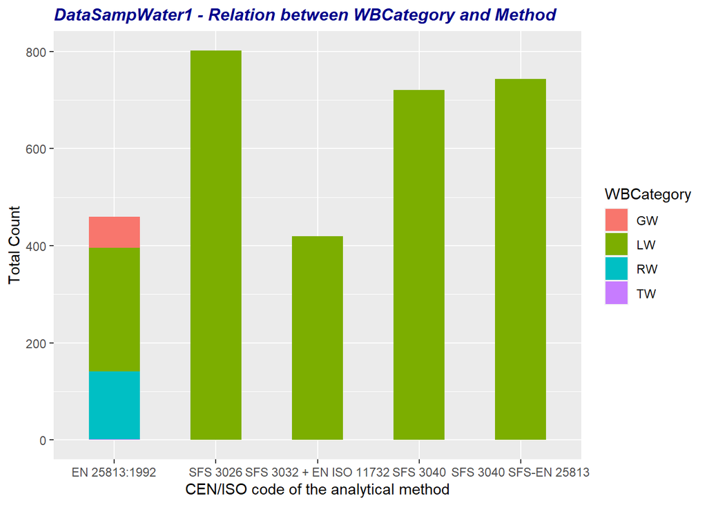

```r
# Plotting the method in relation to WBCategory for all three Datasets

ggplot(DataSampWater1,aes(x = method ,fill = WBCategory)) + geom_bar(width = 0.5) + xlab("CEN/ISO code of the analytical method") + ylab("Total Count")+ggtitle("DataSampWater1 - Relation between WBCategory and Method") + theme(plot.title = element_text(color="dark blue", size=12, face="bold.italic"))
```

[figure not shown]

```r
ggplot(DataSampWater1,aes(x = method ,fill = WBCategory)) + geom_bar(width = 0.5) + xlab("CEN/ISO code of the analytical method") + ylab("Total Count")+ggtitle("DataSampWater2 - Relation between WBCategory and Method") + theme(plot.title = element_text(color="dark blue", size=12, face="bold.italic"))
```

[figure not shown]

```r
ggplot(DataSampWater1,aes(x = method ,fill = WBCategory)) + geom_bar(width = 0.5) + xlab("CEN/ISO code of the analytical method") + ylab("Total Count")+ggtitle("TestWater - Relation between WBCategory and Method") + theme(plot.title = element_text(color="dark blue", size=12, face="bold.italic"))
```

Only one method (EN 25813:1992) is used on all the WBCategories.All other methods are applied only on LW.

### 1.1.9 Relationship between the NSamples and Method in WBcategory

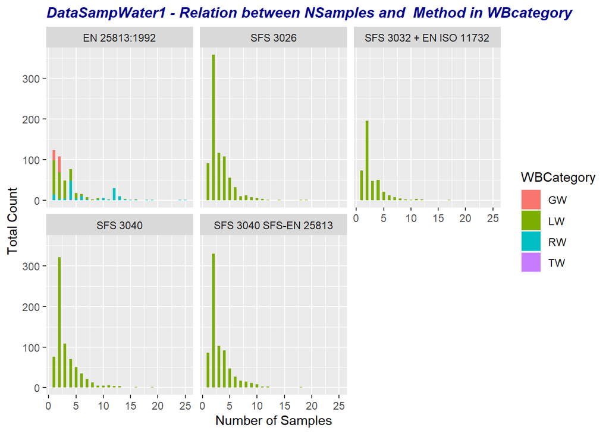

```r
# Plotting the No of samples and  method w.r.t  WBCategory for all three Datasets

ggplot(DataSampWater1,aes(x = NSamples  ,fill = WBCategory)) + geom_bar(width = 0.5) + facet_wrap(~method) +   xlab("Number of Samples") + ylab("Total Count")+ggtitle("DataSampWater1 - Relation between NSamples and  Method in WBcategory") + theme(plot.title = element_text(color="dark blue", size=12, face="bold.italic"))
```

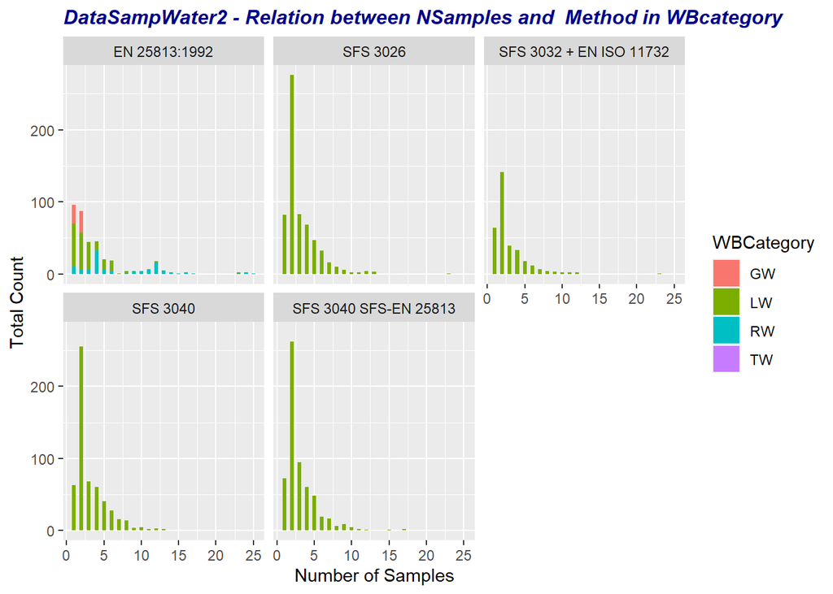

```r
ggplot(DataSampWater2,aes(x = NSamples  ,fill = WBCategory)) + geom_bar(width = 0.5) + facet_wrap(~method) +   xlab("Number of Samples") + ylab("Total Count")+ggtitle("DataSampWater2 - Relation between NSamples and  Method in WBcategory") + theme(plot.title = element_text(color="dark blue", size=12, face="bold.italic"))
```

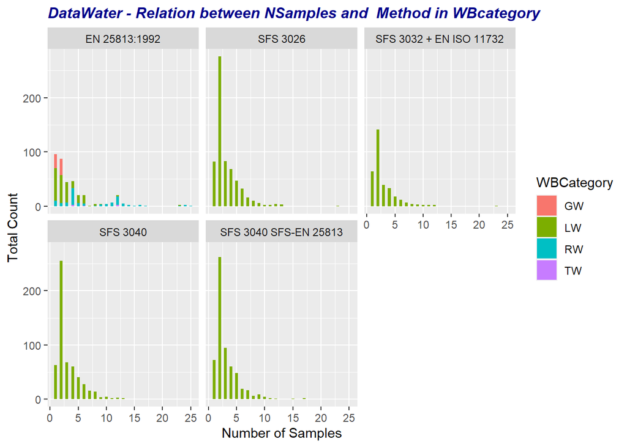

```r
ggplot(TestWater,aes(x = NSamples  ,fill = WBCategory)) + geom_bar(width = 0.5) + facet_wrap(~method) +   xlab("Number of Samples") + ylab("Total Count")+ggtitle("DataWater - Relation between NSamples and  Method in WBcategory") + theme(plot.title = element_text(color="dark blue", size=12, face="bold.italic"))
```

### 1.1.10 Relationship between NSamples and DeterminandC in WBcategory

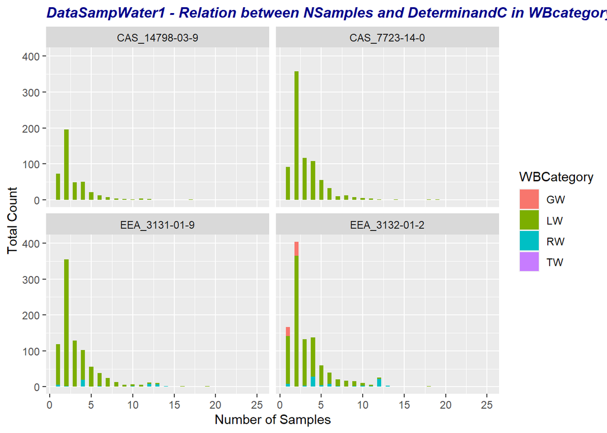

```r
# Plotting the No of samples and  Determinand Code w.r.t  WBCategory for all three Datasets

ggplot(DataSampWater1,aes(x = NSamples  ,fill = WBCategory)) + geom_bar(width = 0.5) + facet_wrap(~determinandC) +   xlab("Number of Samples") + ylab("Total Count")+ggtitle("DataSampWater1 - Relation between NSamples and DeterminandC in WBcategory") + theme(plot.title = element_text(color="dark blue", size=12, face="bold.italic"))
```

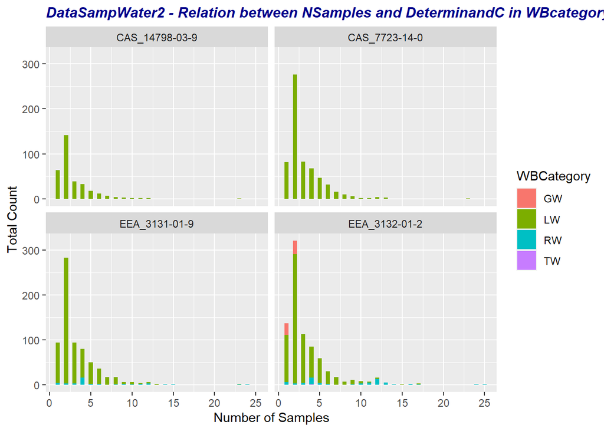

```r
ggplot(DataSampWater2,aes(x = NSamples  ,fill = WBCategory)) + geom_bar(width = 0.5) + facet_wrap(~determinandC) +   xlab("Number of Samples") + ylab("Total Count")+ggtitle("DataSampWater2 - Relation between NSamples and DeterminandC in WBcategory") + theme(plot.title = element_text(color="dark blue", size=12, face="bold.italic"))
```

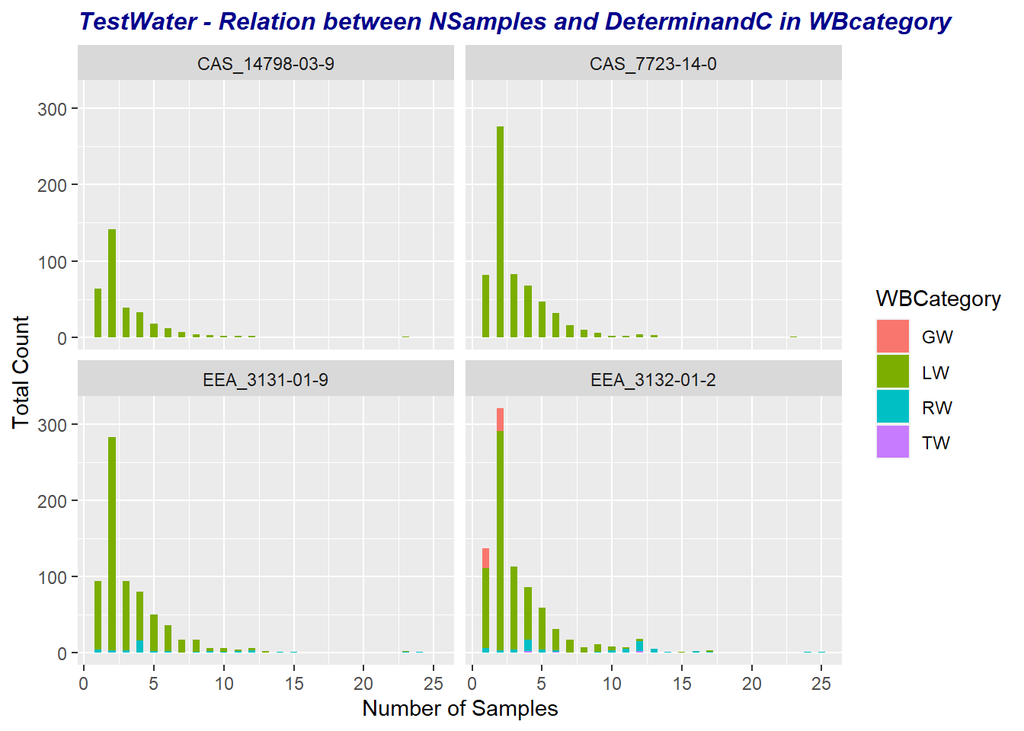

```r
ggplot(TestWater,aes(x = NSamples  ,fill = WBCategory)) + geom_bar(width = 0.5) + facet_wrap(~determinandC) +   xlab("Number of Samples") + ylab("Total Count")+ggtitle("TestWater - Relation between NSamples and DeterminandC in WBcategory") + theme(plot.title = element_text(color="dark blue", size=12, face="bold.italic"))
```

No Relationship between number of samples and DeterminandC.

**Notes for Task 1:**

- The data set has missing values in attribute sd , some of these can be converted to zero , as the sample size is 1. Not enough information provided to recalculate sd. Others need to be checked and decision needs to be taken whether to replace them with mean values or remove them.
- All the media attribute (type of media monitored) is of type - Water, no info on sediment at all, which could indicate missing data.
- All the analysed attribute (fraction of sample analysed) if of type - total, no info on dissolved or SPM, which could indicate missing data.
- Majority of the SiteIDScheme given is of Type euMonitoringSiteCode - something to be aware of.
- A large amount of data is for Lake Water, so the data can be heavily skewed towards it and just two instances for Transitional Water in the combined training dataset, which is bad.

**Highlights of the Water data sets:**

- Data given looks at categories of four Water Body Categories - Ground Water(GW),Lake Water(LW),River Water(RW),Transitional Water (TW)
- There are two types of Site monitoring IDs a majority of which uses euMonitoringSiteCode.
- Data looks at Ammonium, Phosphorus, Dissolved Oxygen and Oxygen Saturation in the water samples.
- Oxygen Saturation is found in all four of the ‘WBCategory’, which is to be expected.
- Ammonium and Phosphorus is found only in Lake water which is interesting in terms of an environmental perspective.
- There are more instances of TW (5) in TestWater, than in the DataSampWater1 and DataSampWater2 (both have one each) , which is interesting. The main difference in the no of WBcategories in the TestWater compared to DataSampWater2 is the addition of 4 TWs. This could be interesting.

## 1.2 Task 1b : Preprocessing data

```r
## Remove the analysed and media - from SampWater 1 , SampWater 2 and TestWater

DataSampWater1$analysed<- NULL
DataSampWater1$media<- NULL
#View(DataSampWater1)              # check if removed successfully
DataSampWater2$analysed<- NULL
DataSampWater2$media<- NULL
TestWater$analysed<- NULL
TestWater$media<- NULL
#View(DataSampWater2)              # check if removed successfully
#View(TestWater)                   # check if removed successfully
```

### 1.2.1 Preprocessing - DataSampwater1

```r
# Remove NA in sd where sample Size = 1 and replace with 0

any(is.na(DataSampWater1$sd))   # check for any NAs in sd column
```

```
## [1] TRUE
```

```r
sum(is.na(DataSampWater1$sd))   # gives the total number of NAs in sd column
```

```
## [1] 314
```

```r
DataSampWater1$sd = ifelse((is.na(DataSampWater1$sd) & (DataSampWater1$NSamples == 1)),0,DataSampWater1$sd) # Check and replace with zero
#view(DataSampWater1)           # View data set to see if it worked.
sum(is.na(DataSampWater1$sd))   # Check to see the number of NAs left after replacement
```

```
## [1] 10
```

Only 10 values left of NA - after replacing suitable NAs as zero - next step: remove or replace with approximate value (mean /Range rule).

```r
#Code to omit rows with NA in sd attribute as % of NAs are very low and  in the Category low on data.

nrow(DataSampWater1)            # to remember the no of rows
```

```
## [1] 3146
```

```r
DataSampWater1 <- na.omit(DataSampWater1)
nrow(DataSampWater1)            # rows numbers after deletion
```

```
## [1] 3136
```

```r
#View(DataSampWater1)           # check to confirm the changes
any(is.na(DataSampWater1$sd))   # Check to see if any NAs left after deletion in sd column
```

```
## [1] FALSE
```

```r
any(is.na(DataSampWater1))      # Check to see if any  other NAs in the data set
```

```
## [1] FALSE
```

No NAs left in the DataSampWater 1

### 1.2.2 Preprocessing -DataSampWater 2

```r
#remove NA in sd where sample Size = 1 and replace with 0

any(is.na(DataSampWater2$sd))    #check for any NAs in the sd column
```

```
## [1] TRUE
```

```r
sum(is.na(DataSampWater2$sd))    # Total number of NAs in the sd column
```

```
## [1] 258
```

```r
DataSampWater2$sd = ifelse((is.na(DataSampWater2$sd) & (DataSampWater2$NSamples == 1)),0,DataSampWater2$sd) # check and replace with 0
#view(DataSampWater2)
sum(is.na(DataSampWater2$sd))    # Total number of NAs left after replacement in the sd column
```

```
## [1] 5
```

```r
# Code to omit rows with NA in sd attribute

nrow(DataSampWater2)            # to remember the number of rows
```

```
## [1] 2485
```

```r
DataSampWater2 <- na.omit(DataSampWater2)
nrow(DataSampWater2)            # number of rows  after deletion
```

```
## [1] 2480
```

```r
#View(DataSampWater2)
any(is.na(DataSampWater2$sd))   # check for any NAs left in the sd Column
```

```
## [1] FALSE
```

```r
any(is.na(DataSampWater2))      # check for any NAs left in the data set
```

```
## [1] FALSE
```

### 1.2.3 Preprocessing - Water

```r
 # remove NA in sd where sample Size = 1 and replace with 0
any(is.na(TestWater$sd))            # check for any NAs left in the sd Column
```

```
## [1] TRUE
```

```r
sum(is.na(TestWater$sd))            # find total number of NAs in the sd column
```

```
## [1] 258
```

```r
TestWater$sd = ifelse((is.na(TestWater$sd) & (TestWater$NSamples == 1)),0,TestWater$sd) # replace sd with zero for Nsample = 1
#view(TestWater)
sum(is.na(TestWater$sd))            # check for number of NAs left after replacement
```

```
## [1] 5
```

```r
# Code to omit remaining rows with NA in sd attribute
nrow(TestWater)                     # to remember the rows
```

```
## [1] 2489
```

```r
TestWater <- na.omit(TestWater)
nrow(TestWater)                     # rows numbers after deletion
```

```
## [1] 2484
```

```r
#View(TestWater)
any(is.na(TestWater$sd))            # check for any NAs left in the sd Column
```

```
## [1] FALSE
```

```r
any(is.na(TestWater))               # check for any NAs left in the data set
```

```
## [1] FALSE
```

## 1.3 Combining the two Data sets

```r
# Combine the two data sets into one - change combined name to Water

nrow(DataSampWater1)                # check the no of rows in DataSampWater 1
```

```
## [1] 3136
```

```r
nrow(DataSampWater2)                # check the no of rows in DataSampWater 2
```

```
## [1] 2480
```

```r
Water <- rbind(DataSampWater1, DataSampWater2)# combine the two as Water
nrow(Water)                         # check the modified no of rows
```

```
## [1] 5616
```

```r
# View(Water)                       # check to confirm the changes
```

## 1.4 Task 1b : Two Tree classifers and one Instance based Classifiers

Choose two tree classifiers and one Instance based classifier with common evaluation method.

Chosen:

- Tree Classifiers:
  - J48
  - LMT
- Instance Based Classifier:
  - Knn
- Evaluation Method:
  - Cross Validation (3 x 10-fold)

```r
#Training the  J48 and LMT  classifiers

#setting ctrl as Cross validation

ctrl <- trainControl(method = "repeatedcv",
                     repeats = 3,             # modified from 3 to 1 (temporarily) to save time during runs
              verboseIter=FALSE)                  # run information is not outputted

# K Value: As a trade-off between high variance (due to low k value) and high bias (due to High k values). Default value of 10  has been kept, which has been shown to provide results that have a more balanced error rate.  The K value chosen also splits the data sample into equal groups, which is perred to keep the sample of the scores (for model skills) are all equivalent.
```

```r
# Train J48 model

set.seed(123)
j48mod <- train(WBCategory ~ ., data = Water,
             method = "J48",
             tuneLength = 12,                 # is the granularity of the tuning parameter grid
             metric = "Accuracy",             # Accuracy is the metric chosen
             trControl = ctrl)

# Train LMT model

set.seed(123)                                 # use same seed as above
lmtmod <- train(WBCategory ~ ., data = Water,
             method = "LMT",
             tuneLength = 12,                 # This is the granularity of the tuning parameter grid
             metric = "Accuracy",             # Accuracy is the metric chosen
             trControl = ctrl)
```

## 1.5 Additional Preprocessing for Knn

```r
# One Hot encoding (OHE)
# Step 1: remove class from the dataset and save as another dataset
# Step 2: binaries those values
# Step 3: bind the binarised value to the removed class
# Step 4: check the new dataset


# Step 1: make a copy
noClass <-Water

# remove the class - it is not transformed
noClass$WBCategory <- NULL


# Step 2: binaries those values

set.seed(123)                                 # use same seed as above

#binarise nominal attributes

binaryVars <- dummyVars(~ ., data = noClass)
newWater <- predict(binaryVars, newdata = noClass)

# Step 3: bind the binarised value to the removed class

binaryWater <-cbind(newWater, Water[2])


# Step 4: check the new dataset

#View(binaryWater)
head(binaryWater, 14)
```

```
##    siteIDScheme.eionetMonitoringSiteCode siteIDScheme.euMonitoringSiteCode
## 1                                      0                                 1
## 3                                      0                                 1
## 4                                      0                                 1
## 5                                      1                                 0
## 6                                      0                                 1
## 7                                      0                                 1
## 8                                      0                                 1
## 9                                      0                                 1
## 10                                     0                                 1
## 11                                     0                                 1
## 12                                     0                                 1
## 13                                     0                                 1
## 14                                     0                                 1
## 15                                     1                                 0
```

[output cut: 75 more lines]

The Water dataset has been correctly one hot encoded

```r
# Normalise and Train the OHE dataset for Knn - training set

set.seed(123)
norm.knn <- train(WBCategory ~ ., data =binaryWater,
method="knn",
tuneLength = 12,
metric = "Accuracy",
preProcess=c("range"), trControl=ctrl)    # Normalisation

#Check the normalised data - as the output of train cannot be viewed

 preProcValues <- preProcess(binaryWater, method = c("range"))
 WaterNormalised <- predict(preProcValues, binaryWater)
 #View(WaterNormalised)
 head(WaterNormalised, 5)
```

```
##   siteIDScheme.eionetMonitoringSiteCode siteIDScheme.euMonitoringSiteCode
## 1                                     0                                 1
## 3                                     0                                 1
## 4                                     0                                 1
## 5                                     1                                 0
## 6                                     0                                 1
##   determinandC.CAS_14798-03-9 determinandC.CAS_7723-14-0
## 1                           0                          0
## 3                           0                          0
## 4                           0                          1
## 5                           0                          0
## 6                           0                          0
##   determinandC.EEA_3131-01-9 determinandC.EEA_3132-01-2   NSamples     minValue
## 1                          1                          0 0.16666667 3.433857e-01
## 3                          1                          0 0.04166667 6.909898e-01
```

[output cut: 21 more lines]

```r
#To check that all the values are on the scale [0, 1] use the summary function.
 summary(WaterNormalised)
```

```
##  siteIDScheme.eionetMonitoringSiteCode siteIDScheme.euMonitoringSiteCode
##  Min.   :0.00000                       Min.   :0.0000
##  1st Qu.:0.00000                       1st Qu.:1.0000
##  Median :0.00000                       Median :1.0000
##  Mean   :0.04469                       Mean   :0.9553
##  3rd Qu.:0.00000                       3rd Qu.:1.0000
##  Max.   :1.00000                       Max.   :1.0000
##  determinandC.CAS_14798-03-9 determinandC.CAS_7723-14-0
##  Min.   :0.0000              Min.   :0.0000
##  1st Qu.:0.0000              1st Qu.:0.0000
##  Median :0.0000              Median :0.0000
##  Mean   :0.1332              Mean   :0.2553
##  3rd Qu.:0.0000              3rd Qu.:1.0000
##  Max.   :1.0000              Max.   :1.0000
##  determinandC.EEA_3131-01-9 determinandC.EEA_3132-01-2    NSamples
##  Min.   :0.0000             Min.   :0.0000             Min.   :0.00000
##  1st Qu.:0.0000             1st Qu.:0.0000             1st Qu.:0.04167
##  Median :0.0000             Median :0.0000             Median :0.04167
##  Mean   :0.2822             Mean   :0.3292             Mean   :0.09237
##  3rd Qu.:1.0000             3rd Qu.:1.0000             3rd Qu.:0.12500
##  Max.   :1.0000             Max.   :1.0000             Max.   :1.00000
##     minValue           meanValue            maxValue
##  Min.   :0.0000000   Min.   :0.0000000   Min.   :0.0000000
##  1st Qu.:0.0001546   1st Qu.:0.0002308   1st Qu.:0.0002342
##  Median :0.0578633   Median :0.0708193   Median :0.0643549
##  Mean   :0.1785946   Mean   :0.2095703   Mean   :0.1885686
##  3rd Qu.:0.3253856   3rd Qu.:0.4893799   3rd Qu.:0.4509039
##  Max.   :1.0000000   Max.   :1.0000000   Max.   :1.0000000
##        sd            method.EN 25813:1992 method.SFS 3026
##  Min.   :0.0000000   Min.   :0.0000       Min.   :0.0000
##  1st Qu.:0.0000265   1st Qu.:0.0000       1st Qu.:0.0000
##  Median :0.0056701   Median :0.0000       Median :0.0000
##  Mean   :0.0496573   Mean   :0.1442       Mean   :0.2553
##  3rd Qu.:0.0355042   3rd Qu.:0.0000       3rd Qu.:1.0000
##  Max.   :1.0000000   Max.   :1.0000       Max.   :1.0000
##  method.SFS 3032 + EN ISO 11732 method.SFS 3040  method.SFS 3040 SFS-EN 25813
##  Min.   :0.0000                 Min.   :0.0000   Min.   :0.000
##  1st Qu.:0.0000                 1st Qu.:0.0000   1st Qu.:0.000
##  Median :0.0000                 Median :0.0000   Median :0.000
##  Mean   :0.1332                 Mean   :0.2283   Mean   :0.239
##  3rd Qu.:0.0000                 3rd Qu.:0.0000   3rd Qu.:0.000
##  Max.   :1.0000                 Max.   :1.0000   Max.   :1.000
##  WBCategory
##  GW: 120
##  LW:5259
##  RW: 235
##  TW:   2
##
##
```

The Water dataset has been now One hot encoded and normalised correctly, the values are in the 0 to 1 scale.

## 1.6 Additional Preprocessing for Knn - Test Water

```r
# One Hot encoding (OHE) and normalise

# Step 1: remove class from the dataset and save as another dataset
# Step 2: binaries those values
# Step 3: bind the binarised value to the removed class
# Step 4:normalise the data
# Step 5: check the new dataset



# Step 1: make a copy
TestnoClass <-TestWater

# remove the class - it is not transformed
TestnoClass$WBCategory <- NULL


# Step 2: binaries those values

set.seed(123)                                       # use same seed as above

#binarise nominal attributes
TestbinaryVars <- dummyVars(~ ., data = TestnoClass)
newTestWater <- predict(TestbinaryVars, newdata = TestnoClass)

# Step 3: bind the binarised value to the removed class

TestbinaryWater <-cbind(newTestWater, TestWater[2])

# Step 4:normalise the  one hot encoded data


 TestpreProcValues <- preProcess(TestbinaryWater, method = c("range"))
 TestWaterNormalised <- predict(TestpreProcValues, TestbinaryWater)

# Step 5: check the new dataset

 #View(TestWaterNormalised)
 head(TestWaterNormalised, 5)
```

```
##   siteIDScheme.eionetMonitoringSiteCode siteIDScheme.euMonitoringSiteCode
## 1                                     0                                 1
## 2                                     1                                 0
## 3                                     0                                 1
## 4                                     0                                 1
## 5                                     0                                 1
##   determinandC.CAS_14798-03-9 determinandC.CAS_7723-14-0
## 1                           0                          1
## 2                           0                          0
## 3                           0                          0
## 4                           0                          0
## 5                           0                          1
##   determinandC.EEA_3131-01-9 determinandC.EEA_3132-01-2   NSamples     minValue
## 1                          0                          0 0.08333333 0.0003942308
## 2                          0                          1 0.12500000 0.0641346154
```

[output cut: 21 more lines]

Test water is now one hot encoded and Normalised.

```r
##Comparing training results on the Merged , Preprocessed dataset

set.seed(123)

# outputs a confusion matrix showing average of instances
confusionMatrix.train(j48mod,norm="average")
```

```
## Cross-Validated (10 fold, repeated 3 times) Confusion Matrix
##
## (entries are average cell counts across resamples)
##
##           Reference
## Prediction    GW    LW    RW    TW
##         GW   9.1   2.7   0.1   0.0
##         LW   2.8 519.6   6.4   0.2
##         RW   0.0   3.6  17.0   0.0
##         TW   0.0   0.0   0.0   0.0
##
##  Accuracy (average) : 0.9717
```

```r
confusionMatrix.train(lmtmod, norm="average")
```

```
## Cross-Validated (10 fold, repeated 3 times) Confusion Matrix
##
## (entries are average cell counts across resamples)
##
##           Reference
## Prediction    GW    LW    RW    TW
##         GW   8.7   2.5   0.0   0.0
##         LW   3.3 519.2   6.5   0.0
##         RW   0.0   4.0  17.0   0.0
##         TW   0.0   0.2   0.0   0.2
##
##  Accuracy (average) : 0.9706
```

```r
confusionMatrix.train(norm.knn, norm="average")
```

```
## Cross-Validated (10 fold, repeated 3 times) Confusion Matrix
##
## (entries are average cell counts across resamples)
##
##           Reference
## Prediction    GW    LW    RW    TW
##         GW   8.8   2.5   0.0   0.0
##         LW   3.2 520.0   6.7   0.2
##         RW   0.0   3.4  16.8   0.0
##         TW   0.0   0.0   0.0   0.0
##
##  Accuracy (average) : 0.9716
```

```r
# norm = overall vs norm = average. Which one to use?
# Main difference is that norm = overall is a percentages, which is easier to interpret
# however ,as TW is very small amount of the total instances ,the percentage is very small and taken as zero, hence norm=average was chosen even though the classification of TW was wrong.
# Accuracy is still the same for both options.
```

for Confusion Matrix norm = “average” was chosen for reasons mentioned in comments above.

## 1.7 Task 1b : Comparison of performance of the Algorithms on Training set

**Confusion Matrix:** Looking at the True positives and True negatives,J48 performs slightly better for GW,KNN for LW,LMT for TW. Similar performance in J48 and LMT for RW.False positives and negatives are similar overall.

**Evaluation method and Size:** K -fold Cross Validation develops several models using different portion of the data and hence is suitable for data of limited size [Ref 3], like this one.

**K Value:** As a trade-off between high variance (due to low k value) and high bias (due to High k values) , k = 10 has been chosen, which has been shown to provide results that have a more balanced error rate [Ref 4]. The K value chosen also splits the data sample into equal groups, which is perred to keep the sample of the scores (for model skills) are all equivalent.

**TuneLength:** The granularity of the tuning parameter grid is chosen to be 12, which is better than the default value of 10.

**Additional Pre-processing for KNN:** One Hot Encoding and Normalisation was done for KNN, as the range of data in the numerical category was quite wide.The higher values would have overwhelmed the smaller values in the Euclidean distance calculations.

```r
#Checking statistical significance

# collect resamples
results <- resamples(list(j48=j48mod,LMT=lmtmod, KNN=norm.knn))
# show results for each model
results
```

```
##
## Call:
## resamples.default(x = list(j48 = j48mod, LMT = lmtmod, KNN = norm.knn))
##
## Models: j48, LMT, KNN
## Number of resamples: 30
## Performance metrics: Accuracy, Kappa
## Time estimates for: everything, final model fit
```

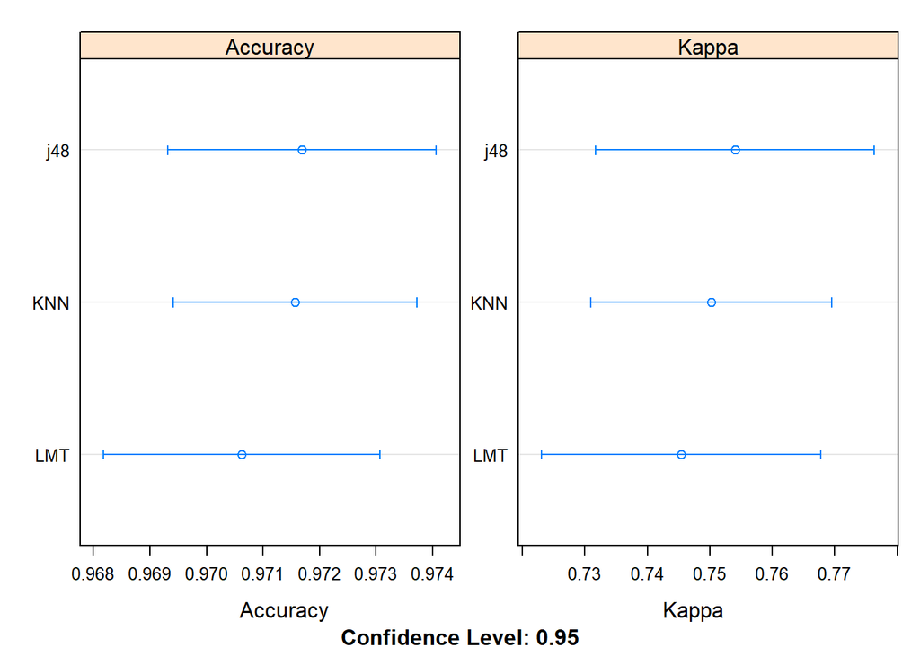

```r
#plot results
scales <- list(x=list(relation="free"), y=list(relation= "free"))
dotplot(results, scales=scales, conf.level = 0.95)
```

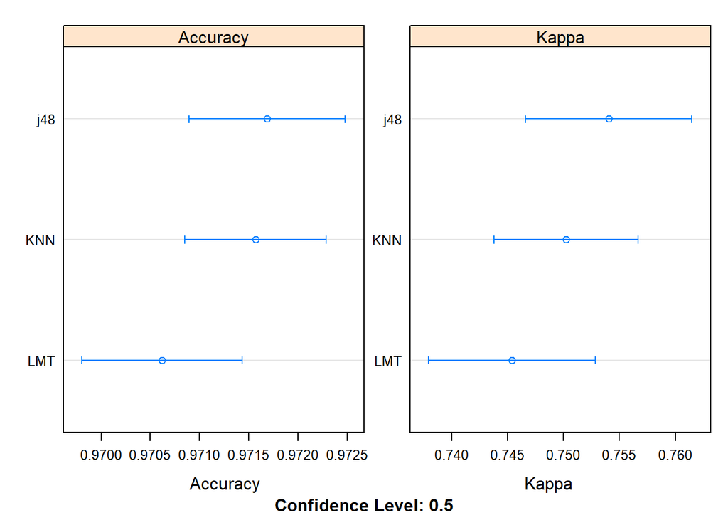

```r
dotplot(results, scales=scales, conf.level = 0.50)
```